# multispectral_drone_svh — interim progress report

Phase 3 saltbush migration done; spectral-species production run in flight

2026-05-20

# 1 What this report is

A snapshot of the project at the end of **Phase 3** of a planned six-phase refactor. Three reusable functions in `funx.R` (`calculate_field_diversity`, `extract_pixel_values`, `calculate_spectral_metrics`) now delegate to the `saltbush` package; three orphaned helpers were deleted. The spectral-species production run is in flight (seeds 1–2 of 20 complete; ~6 h elapsed); the continuous-metrics production results from the previous render still stand, since the swap is verified bit-exact at the Tier 2 fixture level.

Two layers of output appear below:

- **Baselines** — small fixtures (one site, n=99) used by the test harness to verify bit-exact reproducibility. Do **not** read these as manuscript numbers.
- **Production results** — full four-site run at `n = 999, min_points = 133609, seed = 42`. These are the candidate manuscript numbers; the Phase 3 swap did not change them (Tier 2 fixture matches the swapped code path bit-exactly, so the production-scale outputs are mathematically the same).

# 2 Project overview

Code supporting Gemmell *et al.*, “Applying the spectral variability hypothesis to arid shrublands, using multispectral drone imagery.”

The analysis tests whether spectral heterogeneity from drone-borne multispectral imagery (5 bands: blue, green, red, red-edge, NIR) predicts taxonomic plant diversity across four AusPlot sites in arid NSW (NSABHC0009–0012), each surveyed as a 5×5 grid of 20 m subplots.

[output not shown]

The full six-phase plan, with rationale and testing tiers, lives in `CLAUDE.md` at the repo root.

# 3 Phase 2 reproducibility deliverables — please verify

These are the three things most likely to break a reader’s replication six months after publication. Worth signing off before going further.

## 3.1 License split

- **Source code:** MIT License. Permissive, single-paragraph, widely used in scientific code.
- **Data files** in `data/` and the multispectral rasters auto-downloaded from Zenodo: **CC-BY-4.0**, matching the Zenodo deposit (10.5281/zenodo.17089161).

## 3.2 Author list (CITATION.cff)

Taken from the Zenodo data deposit:

- Adele Gemmell — ORCID 0009-0005-2419-7287
- Adrian Fisher — ORCID 0000-0002-6903-8053

If the manuscript author list differs, the `CITATION.cff` at the repo root needs updating before any release.

## 3.3 Seeded rarefaction

`RAREFACTION_SEED <- 42` at the top of `continuous_metrics_analysis.R` propagates through `calculate_spectral_metrics()` and `calculate_coefficient_of_variance()` to the underlying `sample()` calls. End-user runs now reproduce CV/CHV bit-exact. The spectral-species analysis already loops over seeds 1–20 internally and doesn’t need a single global seed.

Verified by running the Tier 2 test (below) twice — both runs produce identical output.

# 4 Baseline outputs

## 4.1 Taxonomic diversity — all four sites

Computed from `data/ausplots_march_24.csv` via `calculate_field_diversity()`.

99 subplots across 4 sites.

Per-site mean taxonomic diversity

| site | n_subplots | mean_richness | mean_shannon | mean_simpson | mean_pielou |
| --- | --- | --- | --- | --- | --- |
| NSABHC0009 | 25 | 10.96 | 2.044 | 0.822 | 0.872 |
| NSABHC0010 | 24 | 2.96 | 0.840 | 0.467 | 0.897 |
| NSABHC0011 | 25 | 7.16 | 1.672 | 0.755 | 0.859 |
| NSABHC0012 | 25 | 8.88 | 1.876 | 0.802 | 0.875 |

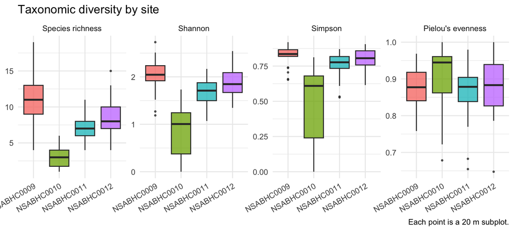

**Data sanity flag:** NSABHC0010 returns 24 subplots instead of 25 — one subplot has no species records and is dropped by `drop_na(standardised_name)` in `calculate_field_diversity()`. Worth confirming this is expected (genuinely bare ground) rather than a data entry gap.

## 4.2 Spectral metrics — Tier 2, NSABHC0010 only

These come from running `extract_pixel_values()` + `calculate_spectral_metrics()` on the smallest raster (the Tier 2 reproducibility test).

> **Important caveat:** the test runs with `n = 99, min_points = 5000, seed = 42` — these are **not** the production-run values (`n = 999, min_points = 133609`). The numbers below should **not** be compared to manuscript values. The purpose of this fixture is to verify that the function produces *identical output across runs*, which it does.

NSABHC0010 spectral metrics (test values)

| subplot_id | CV | SV | CHV_nopca |
| --- | --- | --- | --- |
| 1_1 | 0.1562 | 0.0006 | 0 |
| 1_2 | 0.1363 | 0.0005 | 0 |
| 1_3 | 0.1417 | 0.0005 | 0 |
| 1_4 | 0.1429 | 0.0006 | 0 |
| 1_5 | 0.1467 | 0.0006 | 0 |
| 2_1 | 0.1478 | 0.0006 | 0 |
| 2_2 | 0.1945 | 0.0011 | 0 |
| 2_3 | 0.1422 | 0.0005 | 0 |
| 2_4 | 0.1252 | 0.0004 | 0 |
| 2_5 | 0.1665 | 0.0007 | 0 |
| 3_1 | 0.1297 | 0.0004 | 0 |
| 3_2 | 0.1413 | 0.0005 | 0 |
| 3_3 | 0.1403 | 0.0005 | 0 |
| 3_4 | 0.1366 | 0.0005 | 0 |
| 3_5 | 0.1447 | 0.0005 | 0 |
| 4_1 | 0.1377 | 0.0005 | 0 |
| 4_2 | 0.1650 | 0.0007 | 0 |
| 4_3 | 0.1423 | 0.0005 | 0 |
| 4_4 | 0.1310 | 0.0004 | 0 |
| 4_5 | 0.2165 | 0.0014 | 0 |
| 5_1 | 0.1343 | 0.0005 | 0 |
| 5_2 | 0.1341 | 0.0005 | 0 |
| 5_3 | 0.1337 | 0.0004 | 0 |
| 5_4 | 0.1592 | 0.0007 | 0 |
| 5_5 | 0.1474 | 0.0006 | 0 |

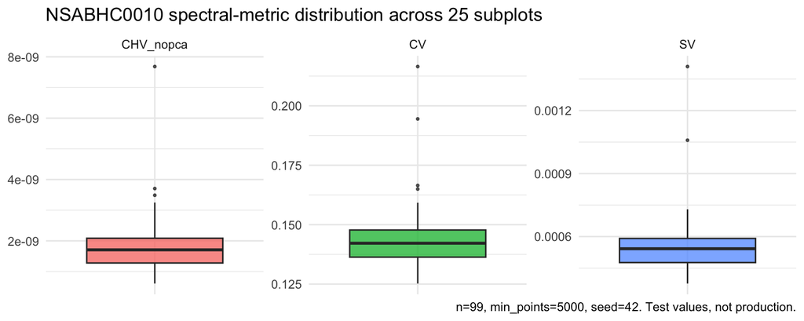

## 4.3 Pixel extraction — NSABHC0010

NSABHC0010: pixel count and per-band mean by subplot

| site | subplot_id | n_pixels | blue | green | red | red_edge | nir |
| --- | --- | --- | --- | --- | --- | --- | --- |
| NSABHC0010 | 1_1 | 367497 | 0.0513 | 0.0579 | 0.0779 | 0.0703 | 0.0871 |
| NSABHC0010 | 1_2 | 212138 | 0.0512 | 0.0579 | 0.0786 | 0.0703 | 0.0868 |
| NSABHC0010 | 1_3 | 636955 | 0.0481 | 0.0562 | 0.0804 | 0.0745 | 0.0917 |
| NSABHC0010 | 1_4 | 565065 | 0.0485 | 0.0559 | 0.0798 | 0.0742 | 0.0912 |
| NSABHC0010 | 1_5 | 204602 | 0.0495 | 0.0576 | 0.0776 | 0.0717 | 0.0896 |
| NSABHC0010 | 2_1 | 706954 | 0.0500 | 0.0574 | 0.0814 | 0.0757 | 0.0937 |
| NSABHC0010 | 2_2 | 284848 | 0.0522 | 0.0608 | 0.0833 | 0.0752 | 0.0932 |
| NSABHC0010 | 2_3 | 569826 | 0.0476 | 0.0561 | 0.0796 | 0.0727 | 0.0895 |
| NSABHC0010 | 2_4 | 181051 | 0.0467 | 0.0538 | 0.0782 | 0.0712 | 0.0871 |
| NSABHC0010 | 2_5 | 420679 | 0.0495 | 0.0571 | 0.0785 | 0.0706 | 0.0876 |
| NSABHC0010 | 3_1 | 542841 | 0.0470 | 0.0556 | 0.0794 | 0.0719 | 0.0882 |
| NSABHC0010 | 3_2 | 243928 | 0.0502 | 0.0574 | 0.0809 | 0.0739 | 0.0908 |
| NSABHC0010 | 3_3 | 241432 | 0.0500 | 0.0577 | 0.0796 | 0.0726 | 0.0896 |
| NSABHC0010 | 3_4 | 399859 | 0.0488 | 0.0564 | 0.0791 | 0.0722 | 0.0886 |
| NSABHC0010 | 3_5 | 722129 | 0.0465 | 0.0547 | 0.0773 | 0.0706 | 0.0874 |
| NSABHC0010 | 4_1 | 637962 | 0.0444 | 0.0528 | 0.0766 | 0.0699 | 0.0858 |
| NSABHC0010 | 4_2 | 330130 | 0.0535 | 0.0602 | 0.0818 | 0.0725 | 0.0899 |
| NSABHC0010 | 4_3 | 410508 | 0.0475 | 0.0560 | 0.0782 | 0.0711 | 0.0880 |
| NSABHC0010 | 4_4 | 396335 | 0.0505 | 0.0570 | 0.0787 | 0.0711 | 0.0880 |
| NSABHC0010 | 4_5 | 276681 | 0.0545 | 0.0638 | 0.0862 | 0.0770 | 0.0957 |
| NSABHC0010 | 5_1 | 133609 | 0.0508 | 0.0581 | 0.0819 | 0.0750 | 0.0923 |
| NSABHC0010 | 5_2 | 601924 | 0.0461 | 0.0546 | 0.0779 | 0.0709 | 0.0869 |
| NSABHC0010 | 5_3 | 443041 | 0.0464 | 0.0547 | 0.0774 | 0.0704 | 0.0867 |
| NSABHC0010 | 5_4 | 285211 | 0.0482 | 0.0562 | 0.0785 | 0.0718 | 0.0888 |
| NSABHC0010 | 5_5 | 154740 | 0.0499 | 0.0562 | 0.0788 | 0.0725 | 0.0898 |

Pixel counts per subplot range from **133,609** to **722,129**. The masked raster excludes non-vegetation pixels (NDVI / NIR / red thresholds applied at preprocessing), so subplots over rockier or barer ground retain fewer pixels — worth confirming the ranking matches site knowledge.

# 5 First end-to-end run — what changed

# 6 Production model results — `continuous_metrics_analysis.R`

Full four-site run, production settings (`n = 999, min_points = 133609, seed = 42`). 12 models = 4 taxonomic metrics × 3 spectral metrics (CV / SV / log.CHV). Site is a random intercept where variance is identifiable; otherwise the model is refit as a fixed-effect linear model.

All twelve continuous-metric models, ordered by p-value.

| taxonomic_metric | spectral_metric | model_type | beta | p_value | r2_marginal | r2_conditional | singular |
| --- | --- | --- | --- | --- | --- | --- | --- |
| inv_simpson | CV | mixed | 1.249 | 6.79e-05 | 0.303 | 0.357 | FALSE |
| species_richness | SV | mixed | -1.279 | 3.49e-03 | 0.073 | 0.763 | FALSE |
| exp_shannon | CV | mixed | 1.479 | 4.57e-03 | 0.307 | 0.395 | FALSE |
| pielou_evenness | log.CHV | fixed | -0.020 | 1.25e-02 | 0.067 | 0.067 | TRUE |
| exp_shannon | SV | mixed | -0.586 | 1.30e-01 | 0.033 | 0.616 | FALSE |
| exp_shannon | log.CHV | mixed | -0.451 | 2.34e-01 | 0.022 | 0.554 | FALSE |
| inv_simpson | log.CHV | mixed | -0.372 | 2.66e-01 | 0.023 | 0.458 | FALSE |
| species_richness | log.CHV | mixed | -0.423 | 3.50e-01 | 0.012 | 0.626 | FALSE |
| species_richness | CV | mixed | 0.862 | 3.74e-01 | 0.065 | 0.470 | FALSE |
| pielou_evenness | CV | fixed | -0.004 | 6.45e-01 | 0.002 | 0.002 | TRUE |
| inv_simpson | SV | mixed | -0.081 | 8.22e-01 | 0.001 | 0.412 | FALSE |
| pielou_evenness | SV | fixed | 0.001 | 9.13e-01 | 0.000 | 0.000 | TRUE |

| total | singular_refit_as_fixed | significant_p_lt_0.05 |
| --- | --- | --- |
| 12 | 3 | 4 |

**Signals worth flagging to the co-author.** Four of twelve relationships clear p < 0.05:

- `inv_simpson ~ CV` — β = +1.25, p = 6.8 × 10⁻⁵ (strongest)
- `species_richness ~ SV` — β = -1.28, p = 0.0035 (note: **negative** — opposite to the usual SVH prediction)
- `exp_shannon ~ CV` — β = +1.48, p = 0.0046
- `pielou_evenness ~ log.CHV` — β = -0.020, p = 0.013 (this is a fixed-effect refit; conditional R² in the table is set equal to marginal R² by convention for the refits)

# 7 Phase 3 — saltbush migration

Three reusable functions in `funx.R` now delegate to the `saltbush` package (`traitecoevo/saltbush`, ≥ `aece6a1`). The signature diff against the locally-installed saltbush (originally pinned to a SHA from November 2024) caught that three relevant upstream PRs had been merged the same morning — adding `group_by_cols` to `calculate_field_diversity` (fixing an off-by-one species-drop bug), an `aoi_id_col` arg + terra migration to `extract_pixel_values`, and a `seed` arg across the rarefaction functions. After reinstalling from HEAD, the swaps were straightforward.

| Function | Approach | Verification |
| --- | --- | --- |
| `calculate_field_diversity` | Local wrapper — AusPlots-specific transect → 5×5 subplot binning (`bin_survey_subplots`) stays local; per-group diversity math delegated via `group_by_cols = c("site_location_name", "subplot_id")` | Tier 1 baseline regenerated; values bit-identical to old fixture, two benign attribute diffs absorbed |
| `extract_pixel_values` | Wrapper that renames `aoi_id` → `subplot_id` and `site_name` → `site` post-call | Tier 2 `pixel_summary` fixture bit-exact (no regeneration) |
| `calculate_spectral_metrics` | Wrapper that handles the input/output column renames and drops the new `image_type` column | Tier 2 `spectral_metrics` fixture bit-exact under `seed = 42` |

`calculate_coefficient_of_variance` (band-subset CV for the red-edge / NIR combinations) stays local rather than upstreamed; it still calls the local `calculate_cv` for that reason. The orphaned `calculate_sv`, `calculate_chv`, and `calculate_chv_nopca` helpers were deleted — `funx.R` is ~150 lines shorter.

# 8 What’s next

In rough order:

1. **Spectral-species run completion** (in flight). 20 seeds × 4 sites of random-forest + k-means clustering. Outputs will land in `data_out/spectral_species_seeds/` (per-seed CSVs) and `data_out/{spectral_species,mean_spectral_species,sr_model,sh_model,si_model}.rds`.
2. **Fold the singular-fit refit logic** into `continuous_metrics_analysis.R` so the next `Rscript` invocation reproduces `data_out/model_fits/` from scratch. Currently the CSV exists but the code that produced it doesn’t live in the repo. Blocks the eventual `tar_make()` in Phase 4.
3. **Optional production re-run of `continuous_metrics_analysis.R`** against the swapped saltbush code path. Tier 2 already proves equivalence; the re-run would refresh `data_out/model_fits/` and provide an extra layer of assurance. Worth doing once spectral-species finishes (memory pressure).
4. **Phase 4 — targets pipeline.** Replace the two imperative scripts with `_targets.R` so the expensive rarefaction and 20-seed clustering cache. CLAUDE.md has the target-graph sketch; `tar_visnetwork()` will eventually supersede it.
5. **Phase 5 — publication prep.** `renv` lockfile, full README rewrite, this report rebuilt as a `tar_render()` target that ties code to claims, Dockerfile, CI, code DOI via Zenodo–GitHub integration.

# 9 Pre-existing issues — now resolved

All four items flagged in the previous report have been addressed and committed:

- `continuous_metrics_analysis.R` `group_by(identifier)` → `group_by(site, subplot_id)`. Committed as `0fa2d8d`.
- `continuous_metrics_analysis.R` `left_join(..., field_diversity, ...)` → `left_join(..., taxonomic_diversity, ...)`. Fixed.
- `spectral_species_analysis.R` undefined `model` at the model-summary lines → now `sr_model` / `sh_model` / `si_model`. Fixed.
- `spectral_species_analysis.R` missing `source('funx.R')` and `survey_data <- read_csv(...)` at the top of the script (it was implicitly relying on a same-session run of `continuous_metrics_analysis.R`). Fixed — the script is now stand-alone.

# 10 Appendix — repo state

Recent commits (most recent first):

```
8c5d322 Phase 3: delete orphaned metric helpers and close out the plan
ac2fe01 Phase 3: delegate calculate_spectral_metrics to saltbush
886f62d Document figures-for-publication.R + Phase 4 figure refactor
6ba5b48 Phase 3: delegate extract_pixel_values to saltbush
859957a Phase 3: delegate calculate_field_diversity to saltbush
61fb231 Add Cornwell and Mesaglio to CITATION.cff
9f72947 Add figures-for-publication.R
888e80f Gitignore manuscript drafts and broaden log pattern
```

Working branch: **`replicate-analysis`**. All commits on this branch are co-authored with Claude Opus 4.7.